# CCP1 - First 2 items and non-DEEPEst DEEP

## 1. Summary

First 2 items significantly predicts search (whether measured as fixations or time spent searching). These effects are at least as strong as when using DEEPEst estimates.

Load packages and data

Merging Qualtrics and mlweb with DEEP data

```r
#### See the 12-21 version of this script for this part; deleted from here since we can just use the completed dataset from after it was run.




c1po<-read.csv("/Users/Kelle/Desktop/pairing 5000 iter w ccp/StanEstimates_Time_parameters_ccp1_EstHier8questions_beta5000.csv")

c1post<-read.csv("/Users/Kelle/Documents/DEEP Kellen/ccp_stochastic/StanEstimates_Time_parameters_ccp1_EstStoch8questions.csv")


cc1<-read.csv("/Users/Kelle/Documents/ccp1_2020-01-07.csv")

s1f16a<-merge(cc1,c1po,by.x="ip",by.y="ipaddress")

s1f16<-merge(s1f16a,c1post,by.x="ip",by.y="ipaddress")


#s1f16<-read.csv("/Users/Kelle/Documents/ccp1_2020-01-07.csv")
```

Coding the continuous total costs DV and chosen interest rate, chosen annual fee, etc.

```r
s1f16$totalcosts<-NA
s1f16$totalcosts[s1f16$trial==1&s1f16$choice=="A"]<-1346
s1f16$totalcosts[s1f16$trial==1&s1f16$choice=="B"]<-1562.25
s1f16$totalcosts[s1f16$trial==1&s1f16$choice=="C"]<-1574.25
s1f16$totalcosts[s1f16$trial==1&s1f16$choice=="D"]<-1552

s1f16$totalcosts[s1f16$trial==2&s1f16$choice=="A"]<-1216.75
s1f16$totalcosts[s1f16$trial==2&s1f16$choice=="B"]<-1064.25
s1f16$totalcosts[s1f16$trial==2&s1f16$choice=="C"]<-951
s1f16$totalcosts[s1f16$trial==2&s1f16$choice=="D"]<-1283.33

s1f16$aprchosen<-NA
s1f16$annual<-NA
s1f16$period<-NA
s1f16$intro<-NA

s1f16$aprchosen[s1f16$correct==1&s1f16$trial==1]<-15.24
s1f16$aprchosen[s1f16$correct==1&s1f16$trial==2]<-10.22


s1f16$nachosen<-0
s1f16$nachosen[s1f16$trial==1&s1f16$choice=="D"]<-1

s1f16$aprchosen[s1f16$nachosen==1]<-14.94

s1f16$aprchosen[s1f16$trial==1&s1f16$choice=="B"]<-19.79

s1f16$aprchosen[s1f16$trial==1&s1f16$choice=="C"]<-20.99

s1f16$chose2lowapr<-0

s1f16$chose2lowapr[s1f16$trial==2&s1f16$choice=="B"]<-1

s1f16$aprchosen[s1f16$chose2lowapr==1&s1f16$correct==0&s1f16$trial==2]<-9.99

s1f16$aprchosen[s1f16$correct==1&s1f16$trial==2]<-10.22

s1f16$aprchosen[s1f16$trial==2&s1f16$choice=="A"]<-13.69

s1f16$aprchosen[s1f16$trial==2&s1f16$choice=="D"]<-14

s1f16$chose0<-NA
s1f16$chose0<-0

s1f16$chose0[s1f16$trial==1&s1f16$choice=="C"]<-1
s1f16$chose0[s1f16$trial==1&s1f16$choice=="B"]<-1

#midnight surge; surge sequin; sequin polaris; polaris midnight
s1f16$chose0[s1f16$trial==2&s1f16$choice=="A"]<-1
s1f16$chose0[s1f16$trial==2&s1f16$choice=="D"]<-1

s1f16$introchosen<-5
s1f16$introchosen[s1f16$chose0==1]<-0
s1f16$introchosen[s1f16$trial==1&s1f16$choice=="D"]<-14.94

s1f16$annual<-NA

s1f16$annual[s1f16$aprchosen==19.79]<-39
s1f16$annual[s1f16$aprchosen==14.94]<-29
s1f16$annual[s1f16$aprchosen==20.99]<-0
s1f16$annual[s1f16$aprchosen==15.24]<-39
s1f16$annual[s1f16$aprchosen==13.69]<-95
s1f16$annual[s1f16$aprchosen==9.99]<-95
s1f16$annual[s1f16$aprchosen==14]<-0
s1f16$annual[s1f16$aprchosen==10.22]<-95

#old incorrect data files:
#write.csv(s1f16, file="/Users/Kelle/Documents/ccp1_16per_addattchosen_2020-01-08.csv")

#s1f1<-read.csv("/Users/Kelle/Documents/ccp1_1per_2020-01-08.csv")
s1f16$logsurveytime<-log10(s1f16$totalsurveytime)

s1f2<-s1f16[(s1f16$fixnumb==1),]
```

## 2. DEEP descriptive statistics

### 2.1 Responses to first DEEP item only

$95 now or $250 in 3 months

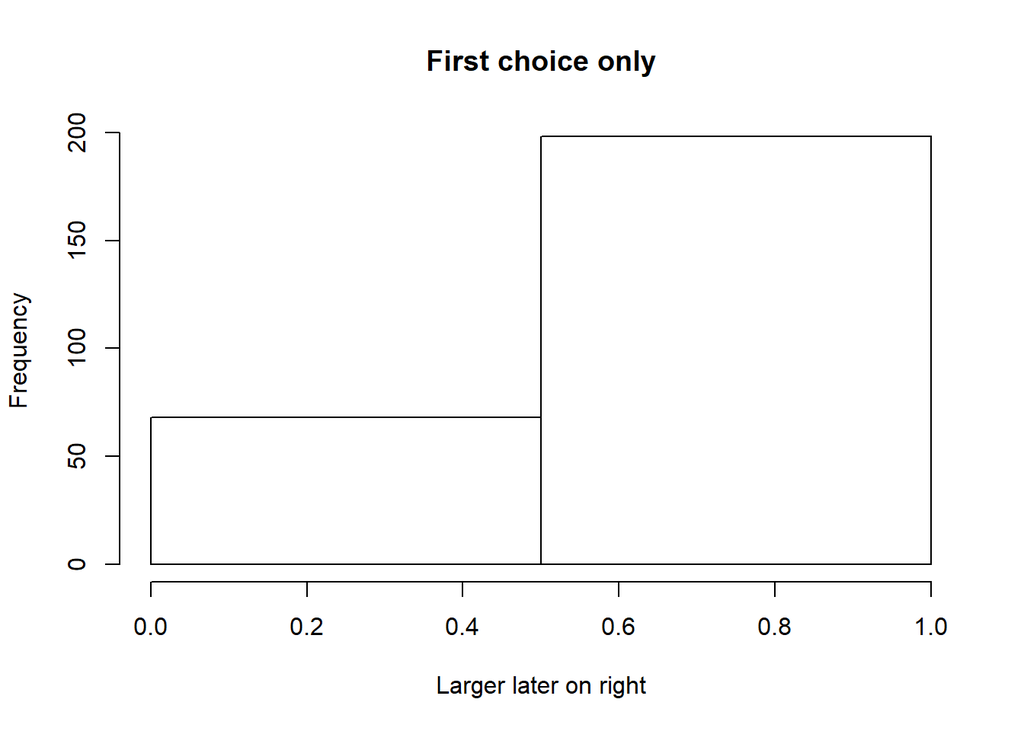

```r
s1f1<-s1f16[(s1f16$fixnumb==1&s1f16$trial==1),]

hist(s1f1$LL_1,breaks=2,main="First choice only",xlab="Larger later on right")
```

```r
table(s1f1$LL_1)
```

```
##
##   0   1
##  68 198
```

### 2.2 First 2 DEEP items

Coded them into 4 groups; 0 = smaller sooner for both, 1 = SS 1st item, LL 2nd item, 2 = LL 1st item, SS 2nd item, 3 = LL for both.

And here are stats broken down by 1st item responses.

Of those who chose LL for first item and therefore saw this item ($248 today or $250 in 1 month), 91% chose SS.

This doesn’t seem ideal. Maybe the priors entered in DEEP are off, but shouldn’t the item generate something where roughly 50% choose each option?

Of those who chose SS for first item and therefore saw this item ($96 today or $300 in 2 weeks), 56% chose SS.

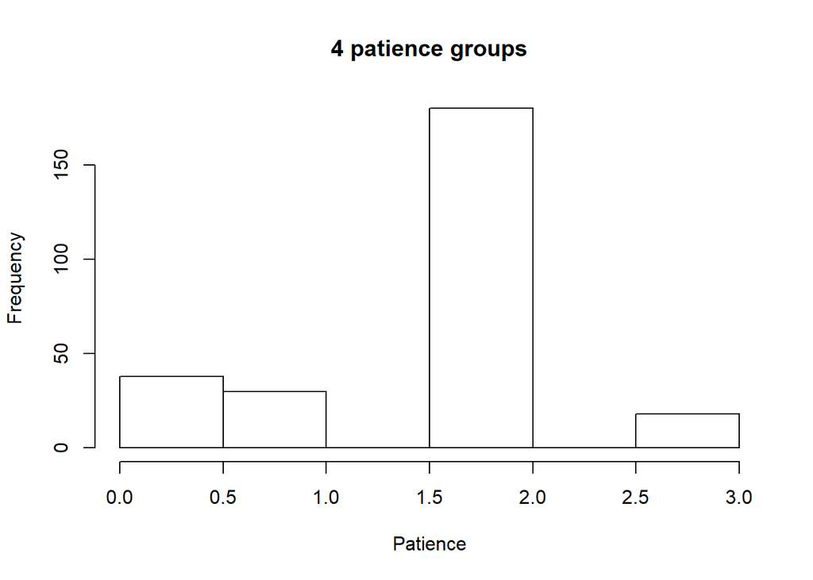

```r
hist(s1f1$patiencegroup4,main="4 patience groups", xlab="Patience")
```

```r
table(s1f1$patiencegroup4)
```

```
##
##   0   1   2   3
##  38  30 180  18
```

### 2.3 Same procedure but for first 3 items (8 groups rather than 4)

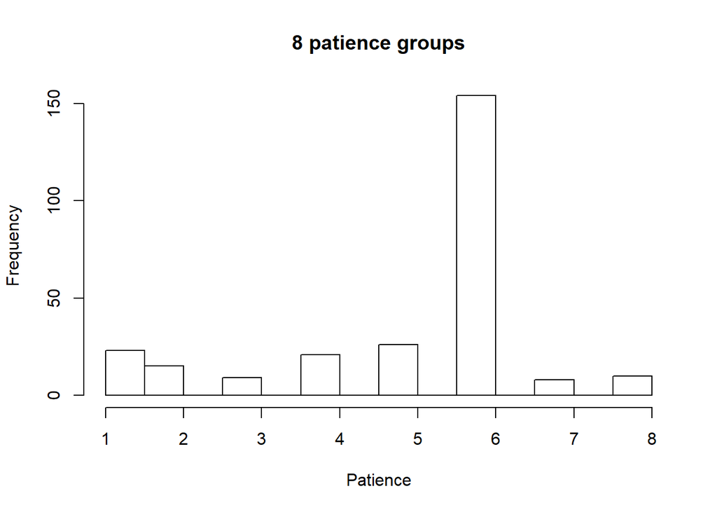

```r
hist(s1f1$patiencegroup8,main="8 patience groups", xlab="Patience")
```

```r
table(s1f1$patiencegroup8)
```

```
##
##   1   2   3   4   5   6   7   8
##  23  15   9  21  26 154   8  10
```

### 2.4 Same procedure but for all 8 items (256 groups)

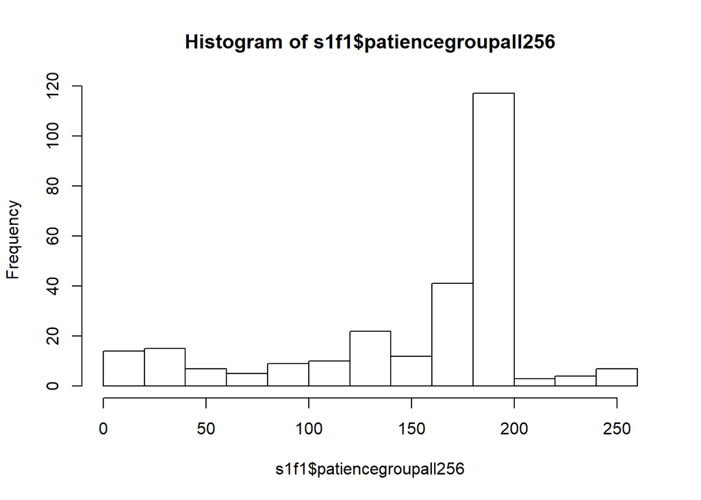

```r
hist(s1f1$patiencegroupall256)
```

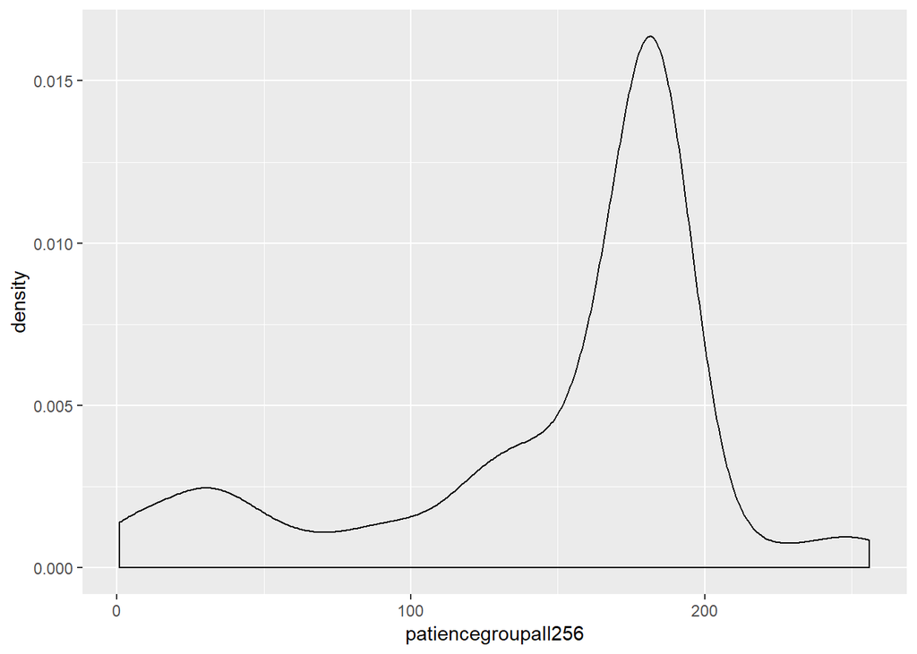

```r
ggplot(s1f1, aes(x = patiencegroupall256)) + geom_density()
```

### 2.5. DEEPEst beta and delta, with 5000 iterations (hier)

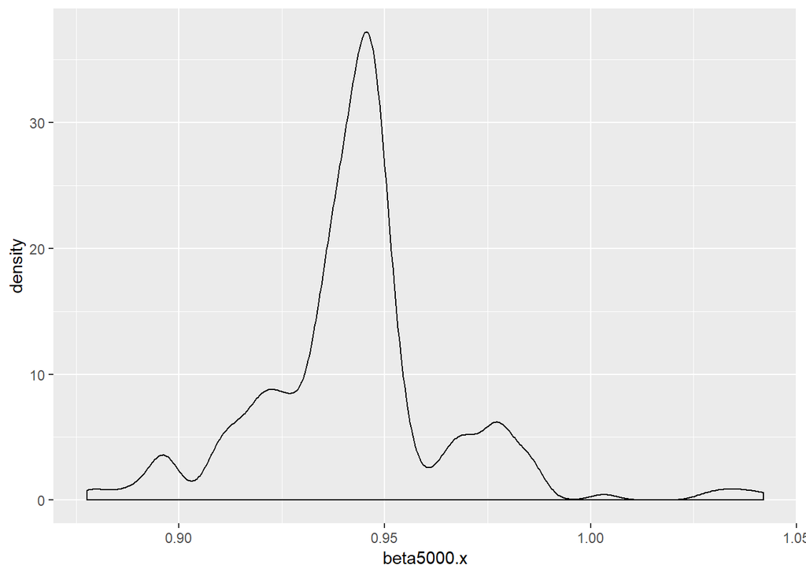

```r
ggplot(s1f1, aes(x = beta5000.x)) + geom_density()
```

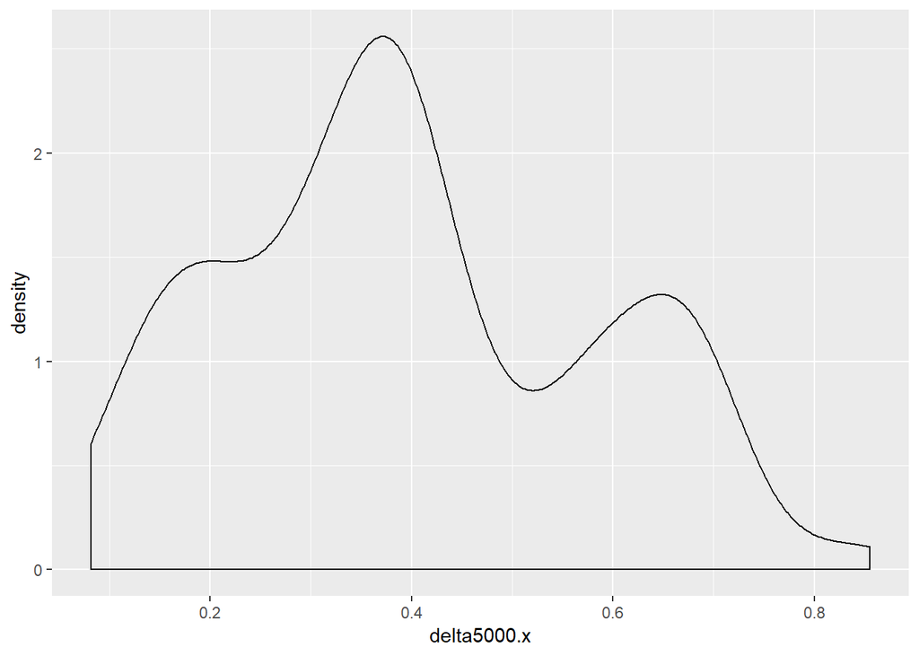

```r
ggplot(s1f1, aes(x = delta5000.x)) + geom_density()
```

### 2.6 DEEPEst beta and delta, stochastic 5000 iter

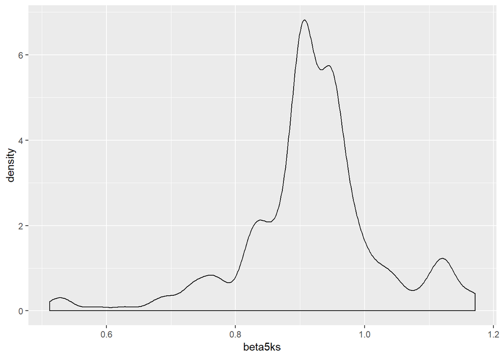

```r
ggplot(s1f1, aes(x = beta5ks)) + geom_density()
```

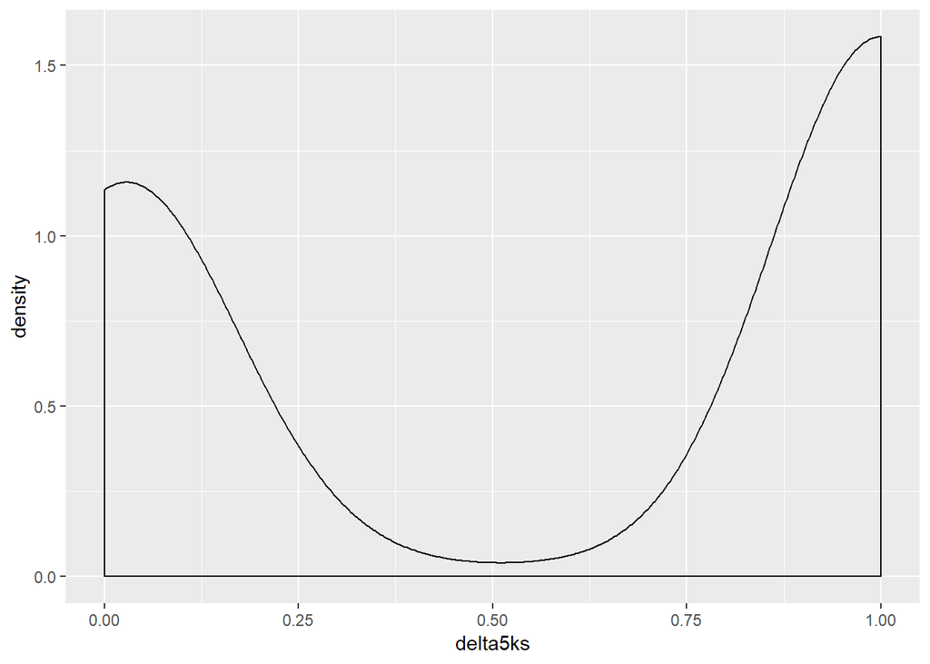

```r
ggplot(s1f1, aes(x = delta5ks)) + geom_density()
```

## 3. Correlations between each DEEP measure

1st and last columns are beta and delta with stochastic DEEPEst.

2nd, 3rd, 4th, and 5th columns are respectively, 1st item only (2 groups), first two items (4 groups), first 3 items (8 groups), and all 8 items (256 groups)

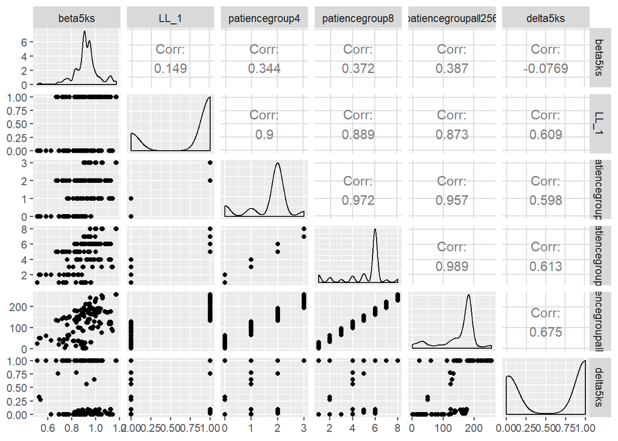

```r
ggpairs(s1f2[,c("beta5ks", "LL_1","patiencegroup4","patiencegroup8", "patiencegroupall256", "delta5ks")])
```

## 4. Adding fixations, search time, and accuracy to the SPLOM plot

First 3 columns are correct (binary), search time, and number of box openings.

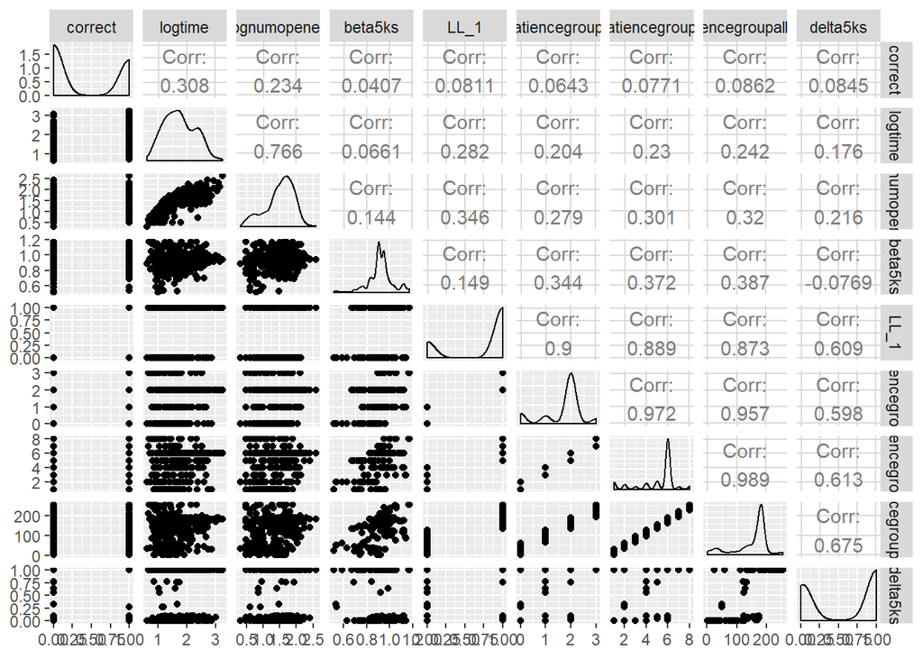

```r
ggpairs(s1f2[,c("correct","logtime","lognumopened","beta5ks", "LL_1","patiencegroup4","patiencegroup8", "patiencegroupall256", "delta5ks")])
```

## 5. I plan to add correlations with financial literacy, numeracy, and other things that should likely be correlated with patience.

## 6. Inferential tests

### 6.1. Two items predicts less time spent searching

It does at least as well as DEEPEst.

1st model is with 2 items of DEEP. 2nd model is with DEEPEst stochastic 5000 iterations

```r
m1a<-lmer(logtime~patiencegroup4+(1|ip),data=s1f2)
summary(m1a)
```

```
## Linear mixed model fit by REML. t-tests use Satterthwaite's method [
## lmerModLmerTest]
## Formula: logtime ~ patiencegroup4 + (1 | ip)
##    Data: s1f2
##
## REML criterion at convergence: 673.6
##
## Scaled residuals:
##      Min       1Q   Median       3Q      Max
## -2.82672 -0.51111 -0.00003  0.51538  2.64580
##
## Random effects:
##  Groups   Name        Variance Std.Dev.
##  ip       (Intercept) 0.18981  0.4357
##  Residual             0.09206  0.3034
## Number of obs: 522, groups:  ip, 266
##
## Fixed effects:
##                 Estimate Std. Error        df t value Pr(>|t|)
## (Intercept)      1.49710    0.06945 265.59737  21.556  < 2e-16 ***
## patiencegroup4   0.14078    0.03743 265.15959   3.761 0.000208 ***
## ---
## Signif. codes:  0 '***' 0.001 '**' 0.01 '*' 0.05 '.' 0.1 ' ' 1
##
## Correlation of Fixed Effects:
##             (Intr)
## patiencgrp4 -0.903
```

```r
m1a2<-lmer(logtime~beta5ks+delta5ks+(1|ip),data=s1f2)
summary(m1a2)
```

```
## Linear mixed model fit by REML. t-tests use Satterthwaite's method [
## lmerModLmerTest]
## Formula: logtime ~ beta5ks + delta5ks + (1 | ip)
##    Data: s1f2
##
## REML criterion at convergence: 674.5
##
## Scaled residuals:
##      Min       1Q   Median       3Q      Max
## -2.82947 -0.52078 -0.01405  0.49963  2.64360
##
## Random effects:
##  Groups   Name        Variance Std.Dev.
##  ip       (Intercept) 0.19195  0.4381
##  Residual             0.09204  0.3034
## Number of obs: 522, groups:  ip, 266
##
## Fixed effects:
##              Estimate Std. Error        df t value Pr(>|t|)
## (Intercept)   1.20323    0.27367 263.12915   4.397  1.6e-05 ***
## beta5ks       0.44249    0.29015 263.20423   1.525 0.128447
## delta5ks      0.21047    0.06311 261.14896   3.335 0.000976 ***
## ---
## Signif. codes:  0 '***' 0.001 '**' 0.01 '*' 0.05 '.' 0.1 ' ' 1
##
## Correlation of Fixed Effects:
##          (Intr) bet5ks
## beta5ks  -0.985
## delta5ks -0.212  0.079
```

### 6.2. Two items predicts fixations/boxes opened

It does at least as well as DEEPEst.

1st model is with 2 items of DEEP. 2nd model is with DEEPEst stochastic 5000 iterations

```r
m1b<-lmer(lognumopened~patiencegroup4+(1|ip),data=s1f2)
summary(m1b)
```

```
## Linear mixed model fit by REML. t-tests use Satterthwaite's method [
## lmerModLmerTest]
## Formula: lognumopened ~ patiencegroup4 + (1 | ip)
##    Data: s1f2
##
## REML criterion at convergence: 416.9
##
## Scaled residuals:
##      Min       1Q   Median       3Q      Max
## -2.76738 -0.42912  0.04391  0.52304  2.35766
##
## Random effects:
##  Groups   Name        Variance Std.Dev.
##  ip       (Intercept) 0.11269  0.3357
##  Residual             0.05726  0.2393
## Number of obs: 522, groups:  ip, 266
##
## Fixed effects:
##                 Estimate Std. Error        df t value Pr(>|t|)
## (Intercept)      1.24022    0.05378 259.95085  23.063  < 2e-16 ***
## patiencegroup4   0.15086    0.02898 259.50152   5.206 3.93e-07 ***
## ---
## Signif. codes:  0 '***' 0.001 '**' 0.01 '*' 0.05 '.' 0.1 ' ' 1
##
## Correlation of Fixed Effects:
##             (Intr)
## patiencgrp4 -0.903
```

```r
m1b2<-lmer(lognumopened~beta5ks+delta5ks+(1|ip),data=s1f2)
summary(m1b2)
```

```
## Linear mixed model fit by REML. t-tests use Satterthwaite's method [
## lmerModLmerTest]
## Formula: lognumopened ~ beta5ks + delta5ks + (1 | ip)
##    Data: s1f2
##
## REML criterion at convergence: 418.8
##
## Scaled residuals:
##      Min       1Q   Median       3Q      Max
## -2.74909 -0.41505  0.05812  0.49755  2.37437
##
## Random effects:
##  Groups   Name        Variance Std.Dev.
##  ip       (Intercept) 0.11423  0.3380
##  Residual             0.05724  0.2392
## Number of obs: 522, groups:  ip, 266
##
## Fixed effects:
##             Estimate Std. Error       df t value Pr(>|t|)
## (Intercept)   0.7529     0.2121 257.4822   3.550 0.000457 ***
## beta5ks       0.6734     0.2248 257.5592   2.995 0.003009 **
## delta5ks      0.2073     0.0489 255.4533   4.239 3.15e-05 ***
## ---
## Signif. codes:  0 '***' 0.001 '**' 0.01 '*' 0.05 '.' 0.1 ' ' 1
##
## Correlation of Fixed Effects:
##          (Intr) bet5ks
## beta5ks  -0.985
## delta5ks -0.212  0.079
```

```r
m2a<-glmer(correct~patiencegroup4+logsurveytime+(1|ip),data=s1f2,family=binomial)
summary(m2a)
```

```
## Generalized linear mixed model fit by maximum likelihood (Laplace
##   Approximation) [glmerMod]
##  Family: binomial  ( logit )
## Formula: correct ~ patiencegroup4 + logsurveytime + (1 | ip)
##    Data: s1f2
##
##      AIC      BIC   logLik deviance df.resid
##    694.1    711.1   -343.1    686.1      518
##
## Scaled residuals:
##     Min      1Q  Median      3Q     Max
## -1.4625 -0.6266 -0.5234  0.8129  1.4489
##
## Random effects:
##  Groups Name        Variance Std.Dev.
##  ip     (Intercept) 1.175    1.084
## Number of obs: 522, groups:  ip, 266
##
## Fixed effects:
##                Estimate Std. Error z value Pr(>|z|)
## (Intercept)     -2.2270     0.6549  -3.401 0.000672 ***
## patiencegroup4   0.2480     0.1572   1.577 0.114738
## logsurveytime    1.5288     0.6121   2.498 0.012504 *
## ---
## Signif. codes:  0 '***' 0.001 '**' 0.01 '*' 0.05 '.' 0.1 ' ' 1
##
## Correlation of Fixed Effects:
##             (Intr) ptncg4
## patiencgrp4 -0.512
## logsurveytm -0.891  0.118
```

```r
m2a2<-glmer(correct~beta5ks+delta5ks+logsurveytime+(1|ip),data=s1f2,family=binomial)
summary(m2a2)
```

```
## Generalized linear mixed model fit by maximum likelihood (Laplace
##   Approximation) [glmerMod]
##  Family: binomial  ( logit )
## Formula: correct ~ beta5ks + delta5ks + logsurveytime + (1 | ip)
##    Data: s1f2
##
##      AIC      BIC   logLik deviance df.resid
##    693.6    714.9   -341.8    683.6      517
##
## Scaled residuals:
##     Min      1Q  Median      3Q     Max
## -1.5340 -0.6343 -0.5125  0.8212  1.4947
##
## Random effects:
##  Groups Name        Variance Std.Dev.
##  ip     (Intercept) 1.154    1.074
## Number of obs: 522, groups:  ip, 266
##
## Fixed effects:
##               Estimate Std. Error z value Pr(>|z|)
## (Intercept)    -3.2257     1.2732  -2.534   0.0113 *
## beta5ks         1.1926     1.1923   1.000   0.3172
## delta5ks        0.5354     0.2612   2.050   0.0404 *
## logsurveytime   1.5338     0.6112   2.509   0.0121 *
## ---
## Signif. codes:  0 '***' 0.001 '**' 0.01 '*' 0.05 '.' 0.1 ' ' 1
##
## Correlation of Fixed Effects:
##             (Intr) bet5ks dlt5ks
## beta5ks     -0.880
## delta5ks    -0.266  0.100
## logsurveytm -0.454  0.007  0.123
```

```r
#m2b<-lmer(totalcosts~patiencegroup4+logsurveytime+trial+(1|ip),data=s1f2)
#summary(m2b)
```

### 6.4 Non-DEEPEst with all 8 items does significantly predict accuracy

```r
m3a<-glmer(correct~patiencegroupall256+logsurveytime+(1|ip),data=s1f2,family=binomial)
summary(m3a)
```

```
## Generalized linear mixed model fit by maximum likelihood (Laplace
##   Approximation) [glmerMod]
##  Family: binomial  ( logit )
## Formula: correct ~ patiencegroupall256 + logsurveytime + (1 | ip)
##    Data: s1f2
##
##      AIC      BIC   logLik deviance df.resid
##    692.4    709.4   -342.2    684.4      518
##
## Scaled residuals:
##     Min      1Q  Median      3Q     Max
## -1.5057 -0.6293 -0.5249  0.8083  1.5716
##
## Random effects:
##  Groups Name        Variance Std.Dev.
##  ip     (Intercept) 1.157    1.075
## Number of obs: 522, groups:  ip, 266
##
## Fixed effects:
##                      Estimate Std. Error z value Pr(>|z|)
## (Intercept)         -2.478671   0.687414  -3.606 0.000311 ***
## patiencegroupall256  0.004351   0.002151   2.022 0.043143 *
## logsurveytime        1.545493   0.610553   2.531 0.011364 *
## ---
## Signif. codes:  0 '***' 0.001 '**' 0.01 '*' 0.05 '.' 0.1 ' ' 1
##
## Correlation of Fixed Effects:
##             (Intr) ptn256
## ptncgrpl256 -0.578
## logsurveytm -0.859  0.121
## convergence code: 0
## Model is nearly unidentifiable: very large eigenvalue
##  - Rescale variables?
## Model is nearly unidentifiable: large eigenvalue ratio
##  - Rescale variables?
```

```r
#m3b<-lmer(totalcosts~patiencegroupall256+logsurveytime+trial+(1|ip),data=s1f2)
#summary(m3b)
```